# ARCANE — Regional Beta Calibration Diagnostics

Grand-Est | ESBL Transmission Rate Estimation

ARCANE Project — MESuRS/Cnam

24 August 2026

```r
library(dplyr)
library(ggplot2)
library(tidyr)
library(knitr)
library(kableExtra)
```

# Overview

This report documents the calibration of within-hospital ESBL transmission rates (β) for a single French administrative region using a stochastic SIS network model.

## What are we trying to do?

We are estimating **β (beta)** — the daily probability that a susceptible patient acquires ESBL from a colonised patient in the same hospital. One β is estimated per facility type (MCO, SSR, etc.) because transmission dynamics differ by care setting.

The calibration works by:

1. Running the simulation thousands of times with different candidate β values
2. At each candidate, comparing the **simulated** ESBL incidence rate to the **observed** rate from SPARES surveillance data
3. Finding the β combination that minimises the **SSE** (sum of squared errors) between simulated and observed incidence

## The simulation model

The model is a **SIS (Susceptible → Infected → Susceptible)** compartmental model running on the real French inter-hospital transfer network (PMSI data). Every simulated day, for every hospital:

- Susceptible patients may acquire ESBL from colonised patients at rate β
- Colonised patients may clear ESBL naturally (mean colonisation duration ≈ 387 days)
- Patients are discharged; a fraction transfer to another hospital via the real transfer network
- Empty beds are filled from the community (5% carry ESBL on admission)

The simulation runs for **2 years**. Only the **last 365 days** are used to measure incidence, allowing the first year to serve as burn-in to reach steady state.

```r
# ── Change REGION_NAME to analyse a different region ─────────────────────────

# [1] "Auvergne-Rhône-Alpes"       "Bourgogne-Franche-Comté"    "Bretagne"                   "Centre-Val de Loire"        "Corse"
# [6] "Grand-Est"                  "Hauts-de-France"            "Île-de-France"              "Normandie"                  "Nouvelle-Aquitaine"
# [11] "Occitanie"                  "Pays de la Loire"           "Provence-Alpes-Côte d'Azur"
REGION_NAME <- "Grand-Est"
region_safe <- gsub("[^A-Za-z0-9_-]", "_", REGION_NAME)

OUT_DIR <- file.path(
  "C:/Users/octariar/OneDrive - LECNAM/Documents/GitHub/arcane-temporal-network-new/optim_cluster_jobs",
  "Outputs", "region", region_safe
)

rds_files <- list.files(OUT_DIR, pattern = "final_validation\\.rds$",
                         recursive = TRUE, full.names = TRUE)
if (length(rds_files) == 0) stop("No final_validation.rds found under: ", OUT_DIR)
rds_files <- sort(rds_files, decreasing = TRUE)
r <- readRDS(rds_files[1])

val <- r$validation_summary

# Colour palette
type_colours <- c(
  "MCO"                             = "#0057B8",
  "SSR"                             = "#C1392B",
  "MCO/SSR"                         = "#9B1D8A",
  "PSY"                             = "#F5A623",
  "HAD"                             = "#00B4D8",
  "Cancer centre (CLCC)"            = "#2ECC71",
  "General public hospital"         = "#0057B8",
  "Private for profit hospital"     = "#E74C3C",
  "Private not-for-profit hospital" = "#9B1D8A",
  "Rehabilitation hospital"         = "#C1392B",
  "University hospital"             = "#F5A623",
  "Unknown"                         = "#555555"
)
```

# 1. Simulation metadata

```r
meta <- data.frame(
  Parameter = c(
    "Region",
    "Hospitals in region (H)",
    "Calibration types",
    "Parallel replicates — objective",
    "Parallel replicates — validation",
    "Cores used",
    "Result file"
  ),
  Value = c(
    r$region,
    r$H_region,
    paste(names(r$incidence_obs), collapse = ", "),
    r$n_rep_obj,
    r$n_rep_valid,
    r$n_cores,
    basename(dirname(rds_files[1]))
  )
)

kable(meta, col.names = c("Parameter", "Value"), align = c("l","l")) %>%
  kable_styling(bootstrap_options = c("striped","hover","condensed"),
                full_width = FALSE)
```

| Parameter | Value |
| --- | --- |
| Region | Grand-Est |
| Hospitals in region (H) | 235 |
| Calibration types | Cancer centre (CLCC), General public hospital, Private for profit hospital, Private not-for-profit hospital, Rehabilitation hospital, University hospital |
| Parallel replicates — objective | 20 |
| Parallel replicates — validation | 50 |
| Cores used | 15 |
| Result file | run_nm_Grand-Est_20260822_071009 |

# 2. Optimisation convergence

## What this tells us

The Nelder-Mead optimiser was started from **multiple starting points** — each a different initial guess for β. This multi-start strategy reduces the risk of the algorithm getting trapped in a local minimum (a β combination that looks locally good but is not the global best).

**How to read this section:**

- Each starting point runs a complete Nelder-Mead trajectory
- The **SSE (sum of squared errors)** at the end of each trajectory tells us how well that starting point’s best β fits the data
- All SSE values being similar = the landscape is well-behaved and the result is reliable
- One SSE far lower than the others = the others got stuck; reassuring as long as at least one start converged
- All SSE = Inf = the optimiser completely failed (data/code issue)

The **best checkpoint** mechanism means that even if a starting point’s final result is slightly worse than an intermediate point it passed through, the globally best β ever seen is always recovered.

## Results

```r
convergence_df <- data.frame(
  Start     = names(r$fit_values),
  SSE       = round(r$fit_values, 6),
  Converged = is.finite(r$fit_values)
) %>% arrange(SSE)

convergence_df %>%
  mutate(
    Best   = ifelse(Start == names(r$fit_values)[r$best_fit_id], "★", ""),
    Status = ifelse(Converged, "✓ Converged", "✗ Did not converge")
  ) %>%
  select(Start, SSE, Status, Best) %>%
  kable(align = c("l","r","l","c")) %>%
  kable_styling(bootstrap_options = c("striped","hover","condensed"),
                full_width = FALSE) %>%
  row_spec(which(convergence_df$SSE == min(convergence_df$SSE, na.rm=TRUE)),
           bold = TRUE, background = "#eaf4fb")
```

|  | Start | SSE | Status | Best |
| --- | --- | --- | --- | --- |
| start_2 | start_2 | 0.011685 | ✓ Converged | ★ |
| start_4 | start_4 | 0.024757 | ✓ Converged |  |
| start_6 | start_6 | 0.039031 | ✓ Converged |  |
| start_1 | start_1 | 0.041759 | ✓ Converged |  |
| start_5 | start_5 | 0.075626 | ✓ Converged |  |
| start_7 | start_7 | 0.155197 | ✓ Converged |  |
| start_3 | start_3 | 0.223606 | ✓ Converged |  |

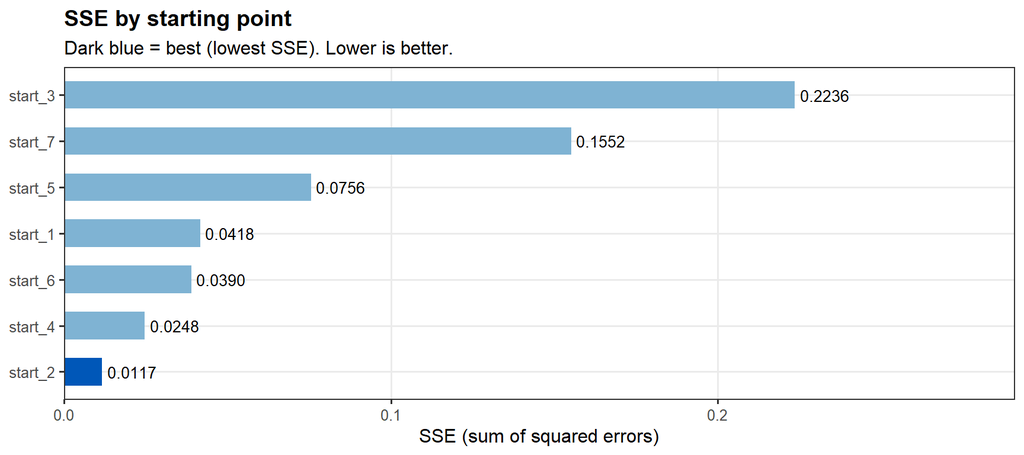

```r
finite_sse <- convergence_df %>% filter(Converged)

if (nrow(finite_sse) > 0) {
  ggplot(finite_sse, aes(x = reorder(Start, SSE), y = SSE)) +
    geom_col(aes(fill = SSE == min(SSE)), width = 0.6, show.legend = FALSE) +
    geom_text(aes(label = formatC(SSE, digits = 4, format = "f")),
              hjust = -0.1, size = 3.5) +
    scale_fill_manual(values = c("FALSE" = "#7fb3d3", "TRUE" = "#0057B8")) +
    scale_y_continuous(expand = expansion(mult = c(0, 0.3))) +
    coord_flip() +
    labs(
      title    = "SSE by starting point",
      subtitle = "Dark blue = best (lowest SSE). Lower is better.",
      x = NULL, y = "SSE (sum of squared errors)"
    ) +
    theme_bw(base_size = 12) +
    theme(plot.title = element_text(face = "bold"),
          panel.grid.minor = element_blank())
}
```

# 3. Iteration history

```r
history_files <- list.files(OUT_DIR, pattern = "history_objective\\.csv$",
                              recursive = TRUE, full.names = TRUE)
hist_df <- if (length(history_files) > 0) {
  read.table(sort(history_files, decreasing = TRUE)[1],
             sep = ";", dec = ".", header = TRUE, stringsAsFactors = FALSE)
} else NULL
```

## What this tells us

This plot shows how the **best SSE discovered so far** evolved across every objective evaluation (every time the simulation was run with a candidate β).

**How to read it:**

- The **x-axis** is the evaluation counter — each tick is one call to the simulator with a specific β
- The **y-axis** is SSE on a log scale — drops represent improvements in fit
- **Blue dots** are evaluations that set a new best SSE; grey dots did not improve
- The **red line** shows the running best SSE — it can only decrease
- A steep early drop followed by a flat line = quick convergence (good)
- Continuous small drops throughout = the algorithm is still exploring (may need more iterations)
- Flat from the start = the warm start was already very close to optimal (best case)

If the red line is still declining steeply at the end, more iterations (`maxit_nm`) would improve the result.

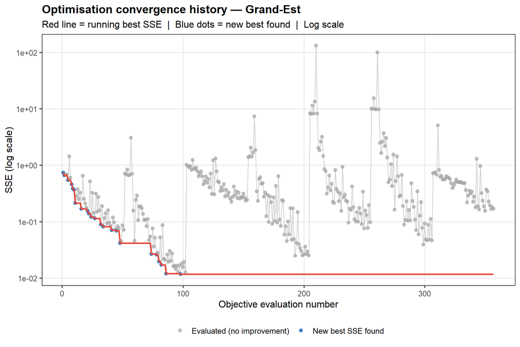

```r
if (!is.null(hist_df) && nrow(hist_df) > 0) {
  ggplot(hist_df, aes(x = eval_counter, y = objective_value)) +
    geom_line(colour = "grey80", linewidth = 0.4) +
    geom_point(aes(colour = is_best), size = 1.8, alpha = 0.7) +
    geom_line(aes(y = best_value), colour = "#E74C3C",
              linewidth = 0.9, linetype = "solid") +
    scale_colour_manual(
      values = c("FALSE" = "grey65", "TRUE" = "#0057B8"),
      labels = c("FALSE" = "Evaluated (no improvement)",
                 "TRUE"  = "New best SSE found")
    ) +
    scale_y_log10() +
    labs(
      title    = paste("Optimisation convergence history —", REGION_NAME),
      subtitle = "Red line = running best SSE  |  Blue dots = new best found  |  Log scale",
      x        = "Objective evaluation number",
      y        = "SSE (log scale)",
      colour   = NULL
    ) +
    theme_bw(base_size = 12) +
    theme(plot.title      = element_text(face = "bold"),
          legend.position = "bottom",
          panel.grid.minor = element_blank())
} else {
  cat("No iteration history file found.")
}
```

# 4. Observed vs simulated incidence

## What this tells us

This is the **primary calibration diagnostic** — the most important plot in this report.

**What it shows:** Each point represents one facility type. The x-axis is the **observed** ESBL incidence from SPARES surveillance (real-world data). The y-axis is the **simulated** incidence produced by the model using the optimal β.

**How to read it:**

- The **dashed diagonal line** is the perfect-fit line (simulated = observed exactly)
- Points **on the diagonal** = the model reproduces that type’s incidence perfectly
- Points **above the diagonal** = the model over-estimates incidence for that type
- Points **below the diagonal** = the model under-estimates incidence for that type
- **Error bars** show ±1 standard deviation across the 50 validation replicates — they reflect the stochastic variability of the simulation, not uncertainty in the observed data. Wide bars mean the simulation is noisy for that type (usually small hospitals or rare types)
- All points close to the diagonal with narrow bars = excellent calibration

**What a “good” result looks like:** Points within ±20% of the diagonal, with error bars that overlap the diagonal. An SSE below ~0.05 is generally considered a good fit for this model.

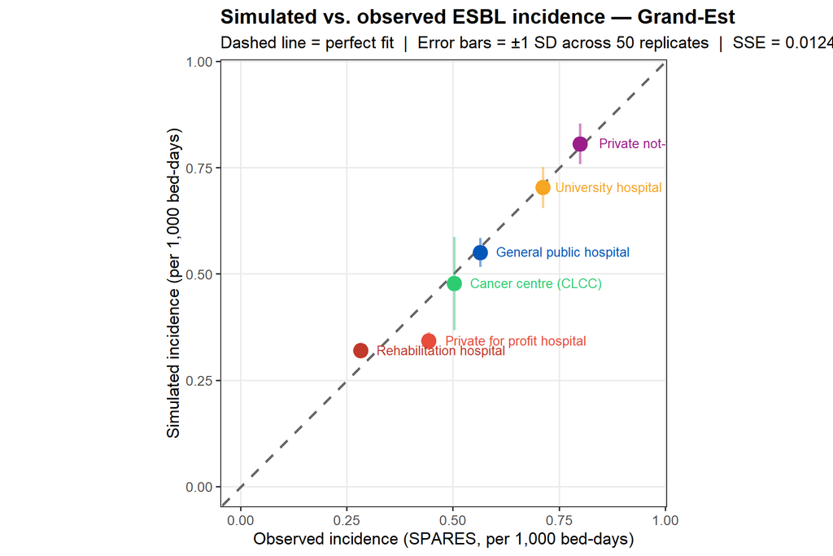

```r
axis_max <- max(c(val$incidence_obs,
                  val$incidence_sim_mean + val$incidence_sim_sd)) * 1.12

ggplot(val, aes(x = incidence_obs, y = incidence_sim_mean, colour = type)) +
  geom_abline(slope = 1, intercept = 0, linetype = "dashed",
              colour = "grey40", linewidth = 0.9) +
  geom_errorbar(aes(ymin = pmax(incidence_sim_mean - incidence_sim_sd, 0),
                    ymax = incidence_sim_mean + incidence_sim_sd),
                width = 0, linewidth = 0.9, alpha = 0.5) +
  geom_point(size = 5) +
  geom_text(aes(label = type),
            hjust = -0.12, vjust = 0.4, size = 3.5,
            show.legend = FALSE) +
  scale_colour_manual(values = type_colours, na.value = "#555555") +
  scale_x_continuous(limits = c(0, axis_max)) +
  scale_y_continuous(limits = c(0, axis_max)) +
  coord_fixed() +
  labs(
    title    = paste("Simulated vs. observed ESBL incidence —", REGION_NAME),
    subtitle = paste0("Dashed line = perfect fit  |  Error bars = ±1 SD across ",
                      r$n_rep_valid, " replicates  |  SSE = ",
                      round(r$sse_final, 4)),
    x        = "Observed incidence (SPARES, per 1,000 bed-days)",
    y        = "Simulated incidence (per 1,000 bed-days)",
    colour   = "Facility type"
  ) +
  theme_bw(base_size = 13) +
  theme(plot.title      = element_text(face = "bold"),
        legend.position = "none",
        panel.grid.minor = element_blank())
```

## Numerical summary

```r
quality <- val %>%
  mutate(
    pct_error = round(100 * diff / incidence_obs, 1),
    ratio     = round(incidence_sim_mean / incidence_obs, 3),
    cv_sim    = round(100 * incidence_sim_sd / incidence_sim_mean, 1)
  ) %>%
  select(type, incidence_obs, incidence_sim_mean, incidence_sim_sd,
         pct_error, ratio, cv_sim, beta, sse)

quality %>%
  rename(
    "Facility type"         = type,
    "Observed (SPARES)"     = incidence_obs,
    "Simulated (mean)"      = incidence_sim_mean,
    "Simulated (SD)"        = incidence_sim_sd,
    "% error"               = pct_error,
    "Sim/Obs ratio"         = ratio,
    "CV% (sim variability)" = cv_sim,
    "β (per day)"           = beta,
    "SSE"                   = sse
  ) %>%
  kable(digits = 4, align = c("l","r","r","r","r","r","r","r","r")) %>%
  kable_styling(bootstrap_options = c("striped","hover","condensed"),
                full_width = TRUE) %>%
  footnote(general = paste0(
    "% error = 100 × (simulated − observed) / observed. ",
    "CV% = coefficient of variation of the simulated incidence across replicates ",
    "(measures simulation noise, not calibration error). ",
    "SSE = (simulated − observed)²."
  ))
```

| Facility type | Observed (SPARES) | Simulated (mean) | Simulated (SD) | % error | Sim/Obs ratio | CV% (sim variability) | β (per day) | SSE |
| --- | --- | --- | --- | --- | --- | --- | --- | --- |
| Cancer centre (CLCC) | 0.5027 | 0.4773 | 0.1094 | -5.1 | 0.949 | 22.9 | 0.0070 | 0.0006 |
| General public hospital | 0.5643 | 0.5504 | 0.0340 | -2.5 | 0.975 | 6.2 | 0.0054 | 0.0002 |
| Private for profit hospital | 0.4428 | 0.3423 | 0.0209 | -22.7 | 0.773 | 6.1 | 0.0063 | 0.0101 |
| Private not-for-profit hospital | 0.7988 | 0.8056 | 0.0481 | 0.9 | 1.009 | 6.0 | 0.0076 | 0.0000 |
| Rehabilitation hospital | 0.2833 | 0.3197 | 0.0186 | 12.8 | 1.128 | 5.8 | 0.0015 | 0.0013 |
| University hospital | 0.7118 | 0.7031 | 0.0479 | -1.2 | 0.988 | 6.8 | 0.0070 | 0.0001 |

Note:  
% error = 100 × (simulated − observed) / observed. CV% = coefficient of variation of the simulated incidence across replicates (measures simulation noise, not calibration error). SSE = (simulated − observed)².

**R² between simulated and observed:** 0.9444

**Mean absolute error:** 0.0319 per 1,000 bed-days

**Total SSE:** 0.012372

# 5. Beta estimates by facility type

## What this tells us

**β (beta)** is the key output of the calibration. It represents the **daily probability of ESBL transmission** from one colonised patient to one susceptible patient sharing the same hospital, assuming they are in contact.

Specifically, at each time step the force of infection felt by susceptible patients in hospital h is:

```
λ_h = 1 − exp(−β_h × I_h / N_h)
```

where I_h is the number of colonised patients and N_h is the total census.

**Interpreting the values:**

- A **higher β** means faster within-hospital spread — more transmissible environment (higher contact rates, more procedures, weaker infection control, etc.)
- A **lower β** means slower spread — lower contact rates or better infection control
- MCO (acute care) typically has higher β than SSR (rehabilitation) because of higher patient turnover, more invasive procedures, and often more vulnerable patients
- **β is not directly observable** — it is a model parameter inferred from the incidence data. Its value depends on the model assumptions (LOS, transfers, etc.)

**Important:** β is specific to this model. It cannot be directly compared to transmission rates from models with different structures.

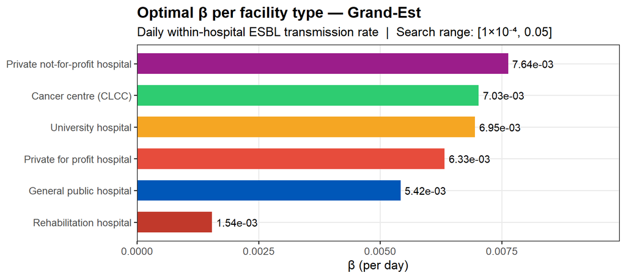

```r
ggplot(val, aes(x = reorder(type, beta), y = beta, fill = type)) +
  geom_col(width = 0.65) +
  geom_text(aes(label = formatC(beta, format = "e", digits = 2)),
            hjust = -0.1, size = 3.8) +
  scale_fill_manual(values = type_colours, na.value = "#555555") +
  scale_y_continuous(expand = expansion(mult = c(0, 0.3))) +
  coord_flip() +
  labs(
    title    = paste("Optimal β per facility type —", REGION_NAME),
    subtitle = paste0("Daily within-hospital ESBL transmission rate  |  ",
                      "Search range: [1×10⁻⁴, 0.05]"),
    x = NULL, y = "β (per day)"
  ) +
  theme_bw(base_size = 13) +
  theme(plot.title      = element_text(face = "bold"),
        legend.position = "none",
        panel.grid.minor = element_blank())
```

# 6. Percentage error by facility type

## What this tells us

This plot directly shows **how wrong** the model is for each facility type, expressed as a percentage of the observed incidence.

**How to read it:**

- **Positive bar (red)** = model over-estimates incidence for this type. The simulated hospitals of this type produce more ESBL cases than observed. Possible causes: β too high for this type, or the model assumes more within-hospital contacts than actually occur
- **Negative bar (blue)** = model under-estimates incidence. The simulation produces fewer cases than observed. Possible causes: β too low, or the observed incidence is inflated by reporting artefacts not captured in the model
- **Short bars (close to 0)** = good fit for that type
- **Long bars (>20%)** = poor fit; the optimal β found for other types may be pulling this type away from its own optimum

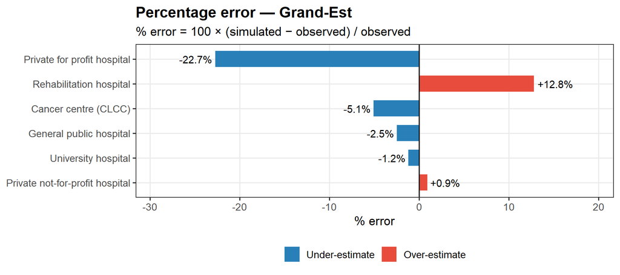

```r
quality %>%
  ggplot(aes(x = reorder(type, abs(pct_error)), y = pct_error,
             fill = pct_error > 0)) +
  geom_col(width = 0.65) +
  geom_hline(yintercept = 0, linewidth = 0.7) +
  geom_text(
    aes(label = paste0(ifelse(pct_error > 0, "+", ""), pct_error, "%"),
        hjust = ifelse(pct_error > 0, -0.1, 1.1)),
    size = 3.8
  ) +
  scale_fill_manual(
    values = c("TRUE" = "#E74C3C", "FALSE" = "#2980B9"),
    labels = c("TRUE" = "Over-estimate", "FALSE" = "Under-estimate")
  ) +
  scale_y_continuous(expand = expansion(mult = c(0.25, 0.25))) +
  coord_flip() +
  labs(
    title    = paste("Percentage error —", REGION_NAME),
    subtitle = "% error = 100 × (simulated − observed) / observed",
    x = NULL, y = "% error", fill = NULL
  ) +
  theme_bw(base_size = 13) +
  theme(plot.title      = element_text(face = "bold"),
        legend.position = "bottom",
        panel.grid.minor = element_blank())
```

# 7. Overall assessment

```r
sse_ok   <- r$sse_final < 0.05
r2_val   <- cor(val$incidence_obs, val$incidence_sim_mean)^2
r2_ok    <- r2_val > 0.90
mae_val  <- mean(abs(val$diff))
mae_ok   <- mae_val < 0.5
conv_ok  <- sum(is.finite(r$fit_values)) >= 2

assessment <- data.frame(
  Metric    = c("Total SSE", "R² (sim vs obs)", "Mean abs. error",
                "Starts converged", "Fit quality"),
  Value     = c(round(r$sse_final, 6),
                round(r2_val, 4),
                paste(round(mae_val, 4), "per 1,000 bed-days"),
                paste(sum(is.finite(r$fit_values)), "of", length(r$fit_values)),
                ifelse(sse_ok & r2_ok & mae_ok, "✓ Good", "⚠ Review needed")),
  Threshold = c("< 0.05 = good", "> 0.90 = good",
                "< 0.50 = good", "≥ 2 = reliable", "")
)

assessment %>%
  kable(align = c("l","r","l")) %>%
  kable_styling(bootstrap_options = c("striped","hover"),
                full_width = FALSE) %>%
  row_spec(5, bold = TRUE,
           background = ifelse(sse_ok & r2_ok & mae_ok, "#d5f5e3", "#fdecea"))
```

| Metric | Value | Threshold |
| --- | --- | --- |
| Total SSE | 0.012372 | < 0.05 = good |
| R² (sim vs obs) | 0.9444 | > 0.90 = good |
| Mean abs. error | 0.0319 per 1,000 bed-days | < 0.50 = good |
| Starts converged | 7 of 7 | ≥ 2 = reliable |
| Fit quality | ✓ Good |  |

*Report generated by ARCANE project — MESuRS/Cnam* *Model: stochastic SIS on PMSI inter-hospital transfer network* *Calibration target: SPARES ESBL incidence by facility type × region*